# EDA of Prosper Loan Data by Vaikunth Kannan

# Abstract

Prosper.com is a P2P lending marketplace, with more than 2 million members. Udacity last updated this data on 03/11/2014.

# Overview of given dataset

# Browse the data

This dataset contains 113937 observations with 81 variables.

Here is the structure of the dataset

```
##  [1] "ListingKey"
##  [2] "ListingNumber"
##  [3] "ListingCreationDate"
##  [4] "CreditGrade"
##  [5] "Term"
##  [6] "LoanStatus"
##  [7] "ClosedDate"
##  [8] "BorrowerAPR"
##  [9] "BorrowerRate"
## [10] "LenderYield"
## [11] "EstimatedEffectiveYield"
## [12] "EstimatedLoss"
## [13] "EstimatedReturn"
## [14] "ProsperRating..numeric."
## [15] "ProsperRating..Alpha."
```

[output cut: 66 more lines]

```
## 'data.frame':    113937 obs. of  81 variables:
##  $ ListingKey                         : Factor w/ 113066 levels "00003546482094282EF90E5",..: 7180 7193 6647 6669 6686 6689 6699 6706 6687 6687 ...
##  $ ListingNumber                      : int  193129 1209647 81716 658116 909464 1074836 750899 768193 1023355 1023355 ...
##  $ ListingCreationDate                : Factor w/ 113064 levels "2005-11-09 20:44:28.847000000",..: 14184 111894 6429 64760 85967 100310 72556 74019 97834 97834 ...
##  $ CreditGrade                        : Factor w/ 9 levels "","A","AA","B",..: 5 1 8 1 1 1 1 1 1 1 ...
##  $ Term                               : int  36 36 36 36 36 60 36 36 36 36 ...
##  $ LoanStatus                         : Factor w/ 12 levels "Cancelled","Chargedoff",..: 3 4 3 4 4 4 4 4 4 4 ...
##  $ ClosedDate                         : Factor w/ 2803 levels "","2005-11-25 00:00:00",..: 1138 1 1263 1 1 1 1 1 1 1 ...
##  $ BorrowerAPR                        : num  0.165 0.12 0.283 0.125 0.246 ...
##  $ BorrowerRate                       : num  0.158 0.092 0.275 0.0974 0.2085 ...
##  $ LenderYield                        : num  0.138 0.082 0.24 0.0874 0.1985 ...
##  $ EstimatedEffectiveYield            : num  NA 0.0796 NA 0.0849 0.1832 ...
##  $ EstimatedLoss                      : num  NA 0.0249 NA 0.0249 0.0925 ...
##  $ EstimatedReturn                    : num  NA 0.0547 NA 0.06 0.0907 ...
##  $ ProsperRating..numeric.            : int  NA 6 NA 6 3 5 2 4 7 7 ...
```

[output cut: 67 more lines]

```
## [1] 113937     81
```

# The main variables which influence the dataset are the borrower characteristics and the propser rating given to each of them.

# Univariate Analysis

Annual income of borrowers

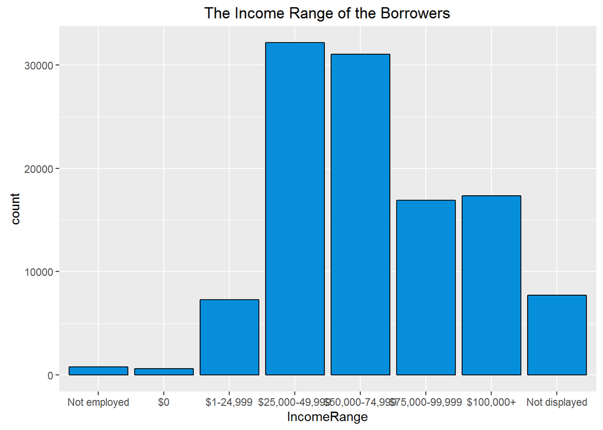

# Histogram of prosper rating

[figure not shown]

```
##    AA     A     B     C     D     E    HR    NA  NA's
##  5372 14551 15581 18345 14274  9795  6935     0 29084
```

# Prosper Score Distribution

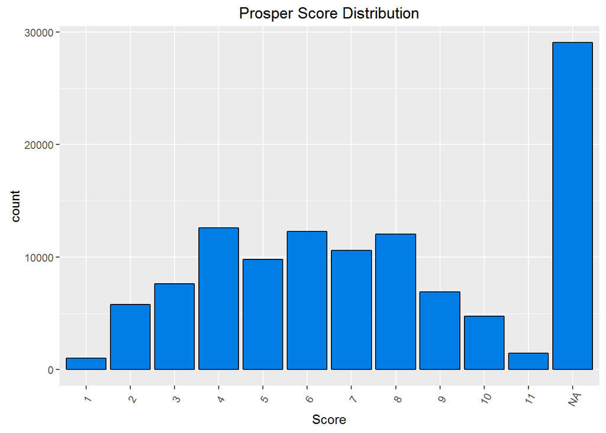

```
##     1     2     3     4     5     6     7     8     9    10    11  NA's
##   992  5766  7642 12595  9813 12278 10597 12053  6911  4750  1456 29084
```

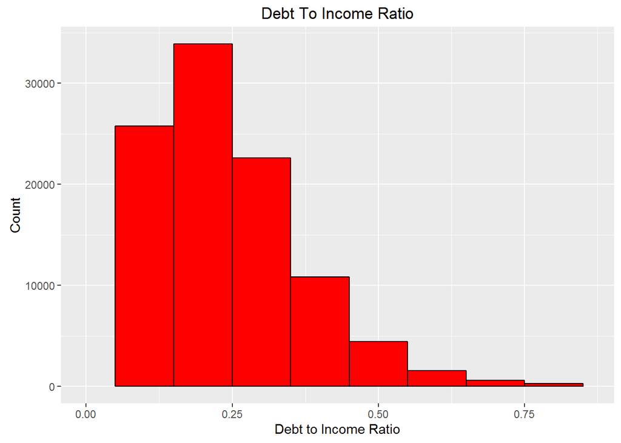

```
##    Min. 1st Qu.  Median    Mean 3rd Qu.    Max.    NA's
##   0.000   0.140   0.220   0.276   0.320  10.010    8554
```

The ratio is around 0.25 which is 25% for most of the borrowers which shows good credit history for the borrowers.

One thing I found on the website was that the terms of the loans were three years long. Lets verify it.

```
## Frequecy Table for Term of the loans
```

```
##
##
##    Cell Contents
## |-------------------------|
## |                       N |
## |         N / Table Total |
## |-------------------------|
##
##
## Total Observations in Table:  113937
##
##
##           |        12 |        36 |        60 |
##           |-----------|-----------|-----------|
##           |      1614 |     87778 |     24545 |
##           |     0.014 |     0.770 |     0.215 |
##           |-----------|-----------|-----------|
##
##
##
##
```

Indeed, 3 year term is the most popular choice.

Lets find out whats the purpose of the loan borrower.

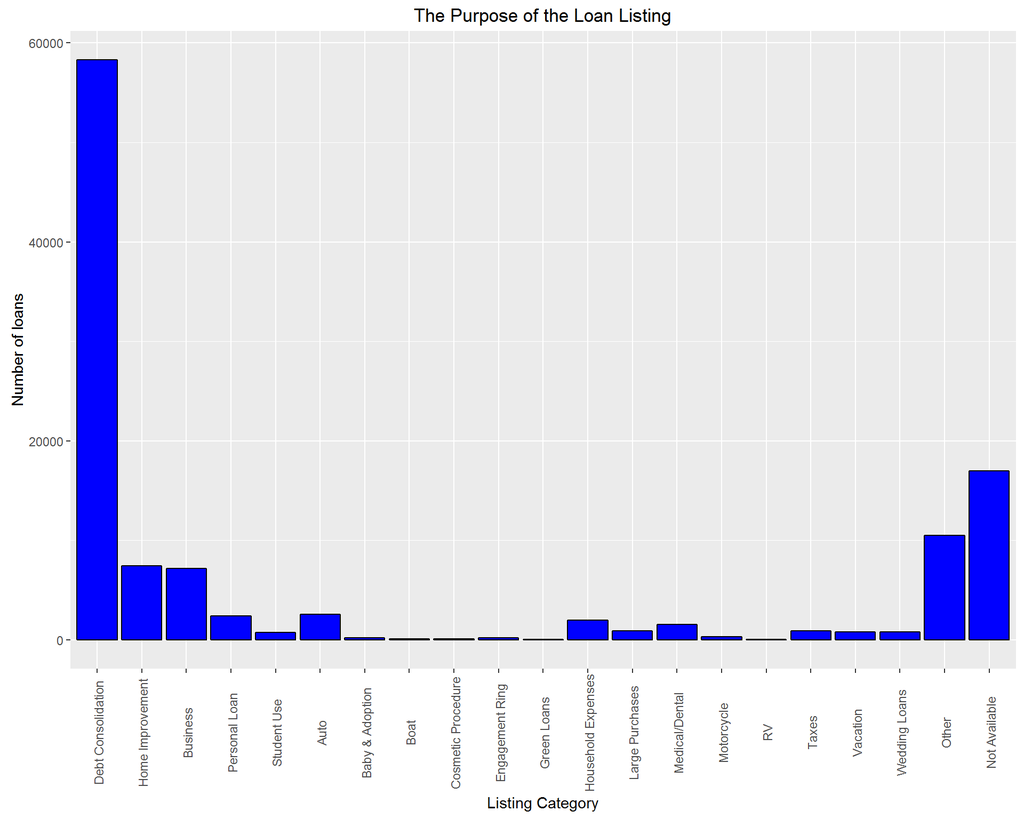

```
## Debt Consolidation   Home Improvement           Business
##              58308               7433               7189
##      Personal Loan        Student Use               Auto
##               2395                756               2572
##    Baby & Adoption               Boat Cosmetic Procedure
##                199                 85                 91
##    Engagement Ring        Green Loans Household Expenses
##                217                 59               1996
##    Large Purchases     Medical/Dental         Motorcycle
##                876               1522                304
##                 RV              Taxes           Vacation
##                 52                885                768
##      Wedding Loans              Other      Not Available
##                771              10494              16965
```

So many people give the purpose as debt consolidation. Also, a lot of loans have no purpose which needs to be investigated. As usual, significant number of people have invested in Auto, Household and Medical Expenses.

Lets take a look at the Loan Start date

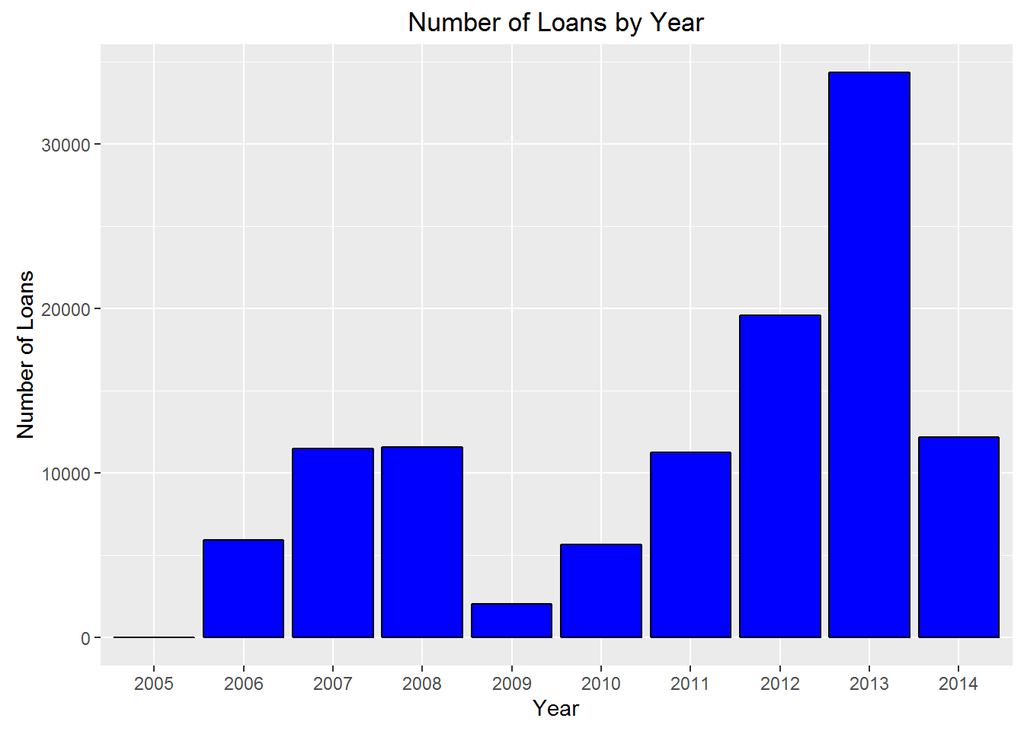

```
##    Min. 1st Qu.  Median    Mean 3rd Qu.    Max.
##    2005    2008    2012    2011    2013    2014
```

Since the data is upto 2014 we can see that lot of borrowers are after 2012 which is a period of recovery after the global recession.

Splitting the Loan data by the month of borrowing.

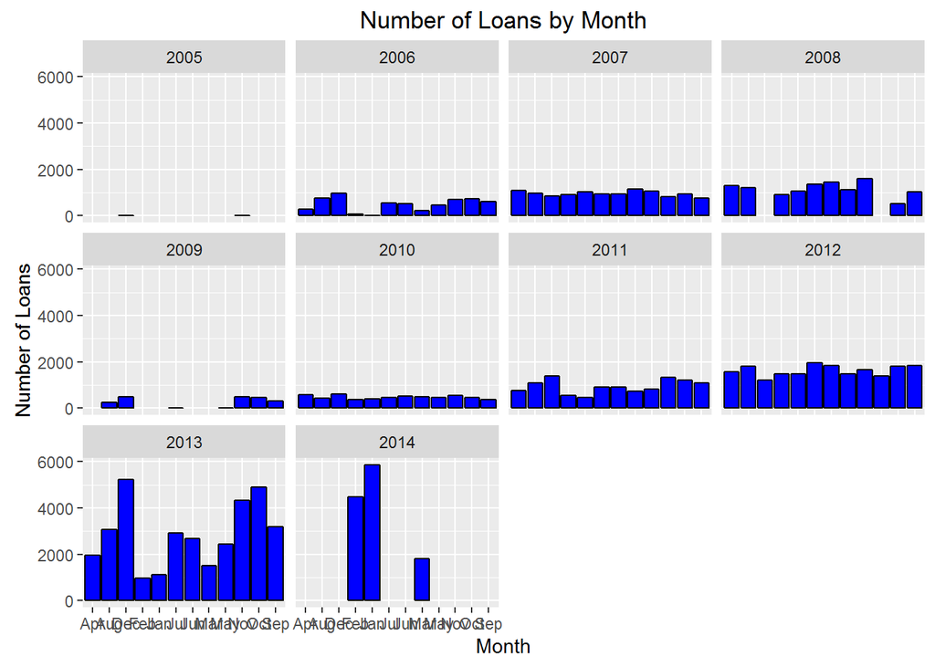

The amount of loan each borrower has taken.

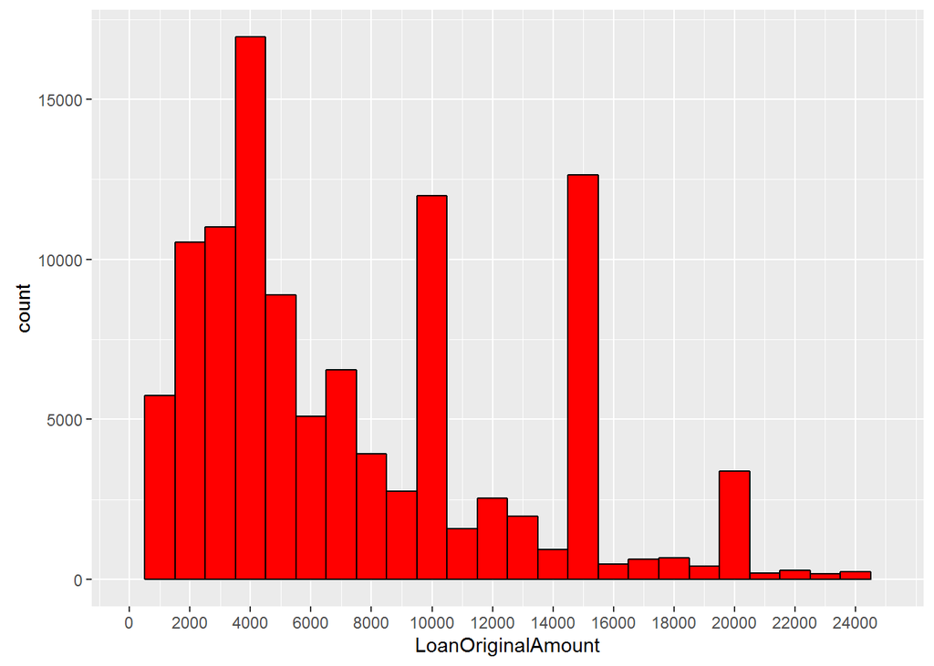

```
##    Min. 1st Qu.  Median    Mean 3rd Qu.    Max.
##    1000    4000    6500    8337   12000   35000
```

To get more insight, we can see whether people were employed when they obtained the loan which would define the purpose of loan.

[figure not shown]

```
##                    Employed     Full-time Not available  Not employed
##          2255         67322         26355          5347           835
##         Other     Part-time       Retired Self-employed
##          3806          1088           795          6134
```

This data seems satisfying as most of the people are employed and in full time jobs.

There are some cases where people are referred to banks to get loans. Lets see how many people obtained loans through referrals.

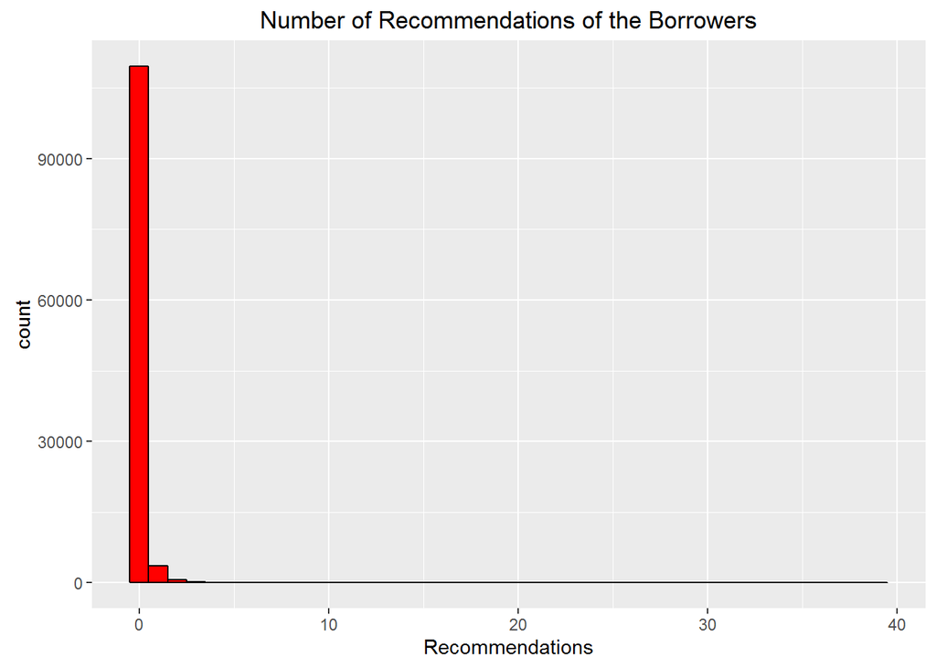

```
## If the borrower has one or
##       more recommendations
##  FALSE   TRUE
## 109678   4259
```

Since the value of 0 is high, majority of them did not have a recommendation.

Then, what was the monthly income of the borrowers that made them eligible for loans,

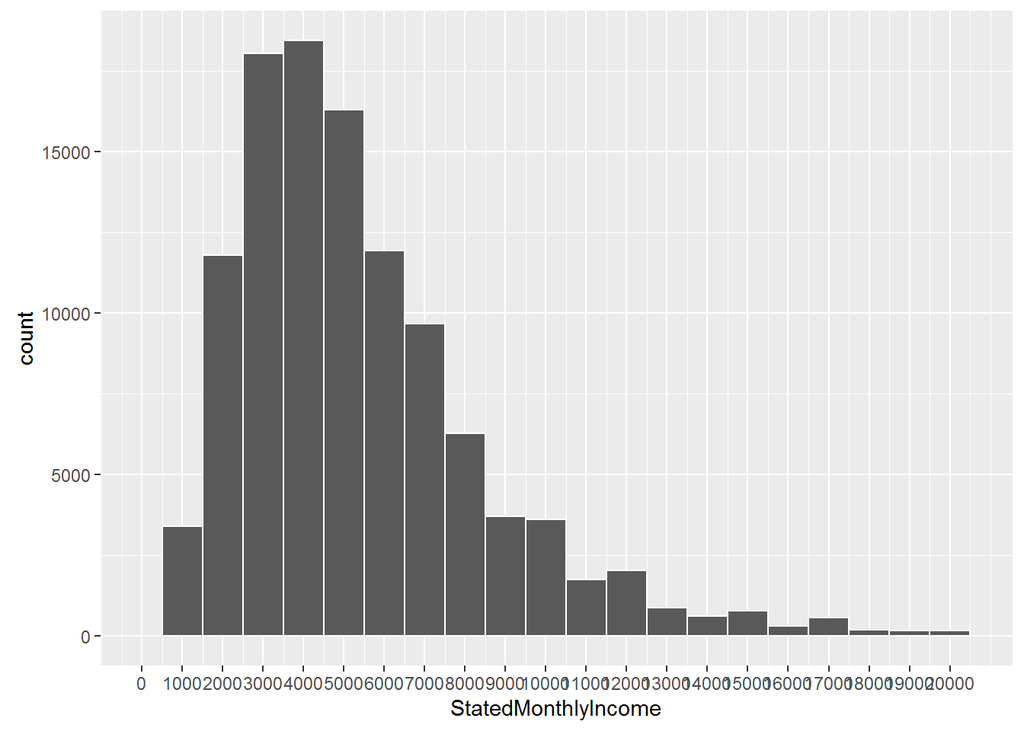

```
##    Min. 1st Qu.  Median    Mean 3rd Qu.    Max.
##       0    3200    4667    5608    6825 1750000
```

This correlates with the loan amount being borrowed being around the 4000 range since the mean and median montly income are in the same range and people are sensible to take loan which they are able to repay.

Looking at the bank’s or lenders perspective, lets see if lenders are benefitting from the loan

```r
summary(prosper$LenderYield)
```

```
##    Min. 1st Qu.  Median    Mean 3rd Qu.    Max.
## -0.0100  0.1242  0.1730  0.1827  0.2400  0.4925
```

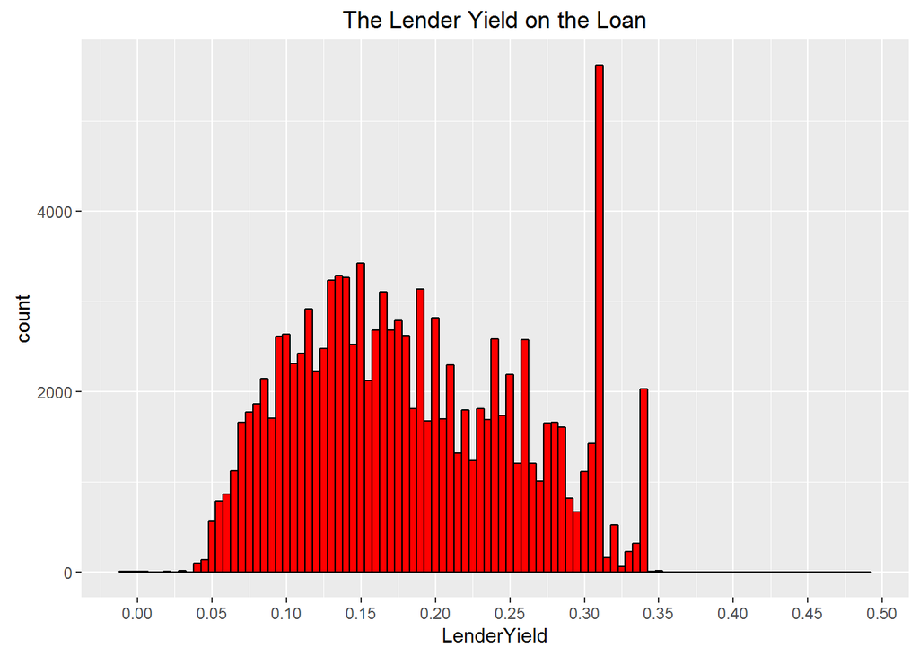

```r
qplot(x=LenderYield, data=prosper, binwidth = 0.005, color = I('black'), fill = I('red')) +
    scale_x_continuous(breaks=seq(0, 0.5, 0.05)) +
    labs(title="The Lender Yield on the Loan")
```

The plot shows that the lender yield is high at 0.31 which shows that lenders also had a good investment out of giving loans.

The number of investors investing in a loan can be determined to see how the funding occurs

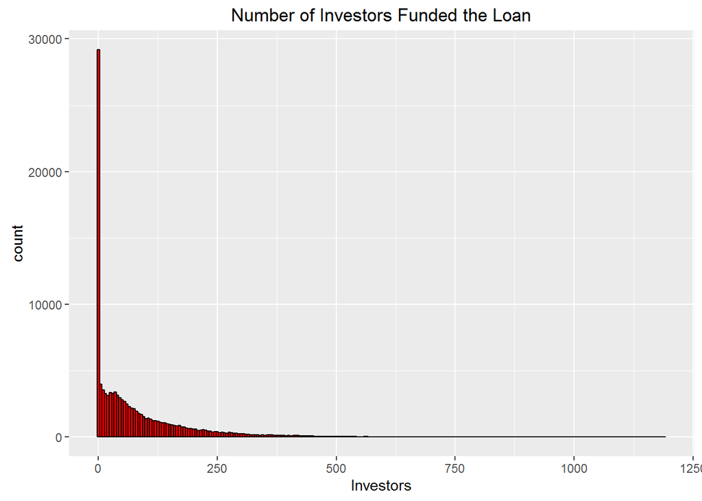

```
##
## FALSE  TRUE
## 86123 27814
```

## Bivariate Analysis

Since the loan amount are pretty low, usually the loans could be from relatives or friends.

```
## if the single investor is
##            a friend of the borrower
##     0     1
## 27732    82
```

But, from this data, borrowers have taken loans mostly not through friends.

Does the prosper rating mean there are lot of borrowers?

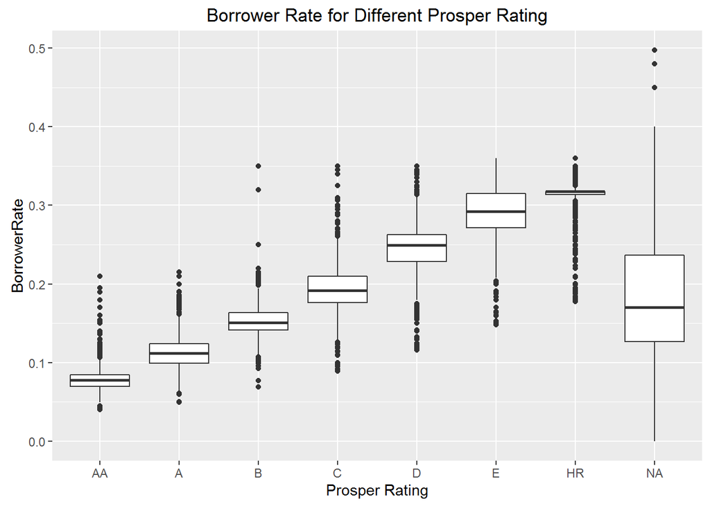

So, borrowers with higher prosper rating are not the majority ones to take loans.

Does the rating exactly describe the credibility and repayment capacity of the borrower?

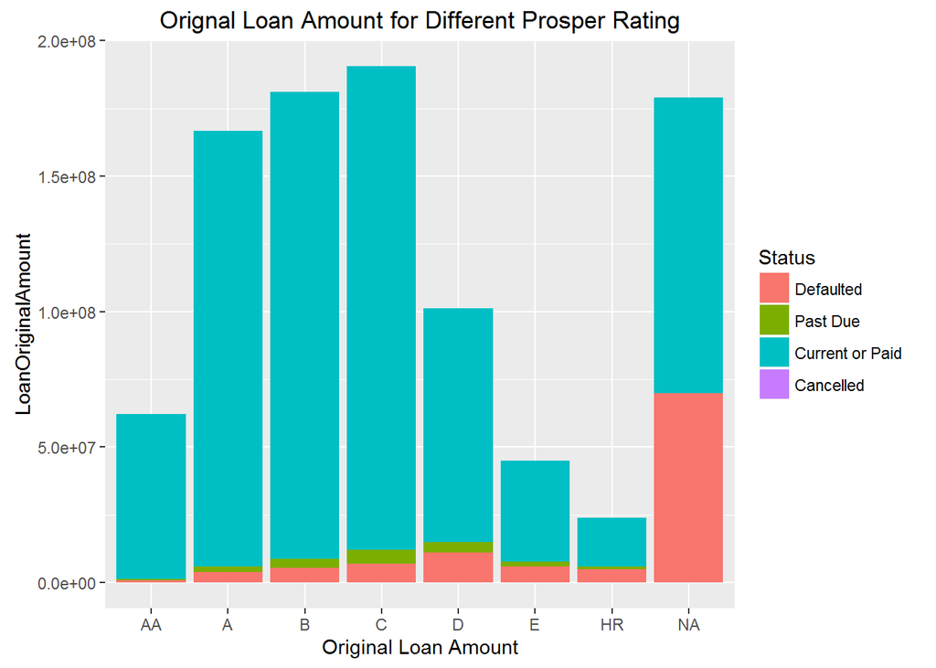

The loans with E and HR have less defaulting but the number of loans in that category are pretty less. The higher the rating the number of loans defaulted has decreased adding to the authenticity of the rating.

Some people take the risk of obtaining loan with repayment higher than their monthly income. Lets see how many people have taken that risk to get a loan from prosper.

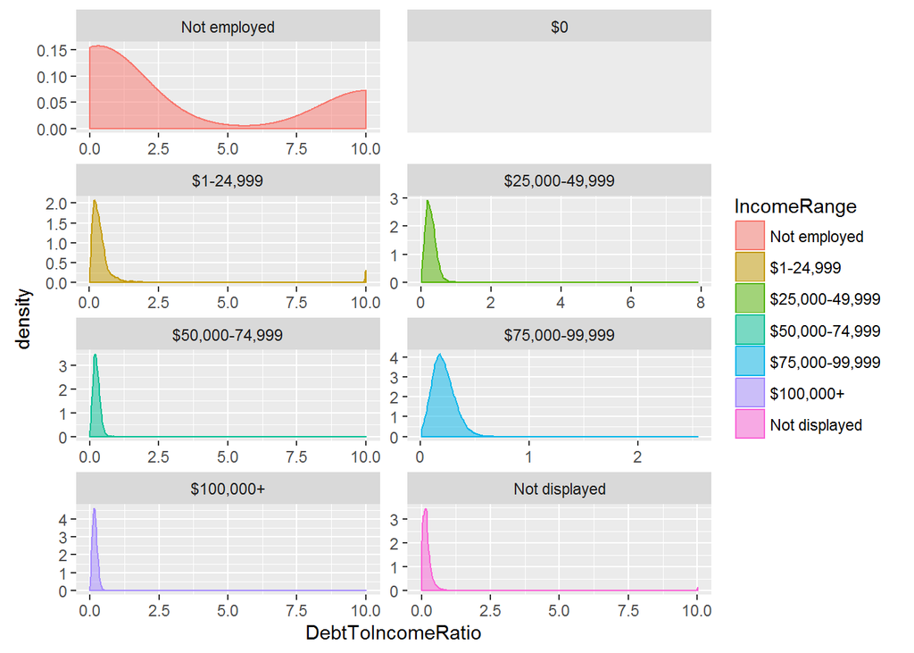

```r
ggplot(aes(x=DebtToIncomeRatio), data=prosper) +
    geom_density(aes(color = IncomeRange,
                     fill  = IncomeRange),
                 alpha = 0.5) +
    facet_wrap(~IncomeRange, ncol=2,
               scales = "free")
```

```r
with(prosper, by(DebtToIncomeRatio, IncomeRange,
              summary))
```

```
## IncomeRange: Not employed
##    Min. 1st Qu.  Median    Mean 3rd Qu.    Max.    NA's
##   0.010   0.160   0.295   3.328  10.010  10.010     728
## --------------------------------------------------------
## IncomeRange: $0
##    Min. 1st Qu.  Median    Mean 3rd Qu.    Max.    NA's
##      NA      NA      NA     NaN      NA      NA     621
## --------------------------------------------------------
## IncomeRange: $1-24,999
##    Min. 1st Qu.  Median    Mean 3rd Qu.    Max.    NA's
##   0.020   0.190   0.320   0.737   0.500  10.010     913
## --------------------------------------------------------
## IncomeRange: $25,000-49,999
##    Min. 1st Qu.  Median    Mean 3rd Qu.    Max.    NA's
##  0.0100  0.1700  0.2600  0.2789  0.3600  7.9000    2311
## --------------------------------------------------------
## IncomeRange: $50,000-74,999
##    Min. 1st Qu.  Median    Mean 3rd Qu.    Max.    NA's
##  0.0100  0.1600  0.2300  0.2457  0.3200 10.0100    1690
## --------------------------------------------------------
## IncomeRange: $75,000-99,999
##    Min. 1st Qu.  Median    Mean 3rd Qu.    Max.    NA's
##  0.0100  0.1400  0.2000  0.2137  0.2800  2.5500     901
## --------------------------------------------------------
## IncomeRange: $100,000+
##    Min. 1st Qu.  Median    Mean 3rd Qu.    Max.    NA's
##  0.0000  0.1200  0.1700  0.1806  0.2300 10.0100    1266
## --------------------------------------------------------
## IncomeRange: Not displayed
##    Min. 1st Qu.  Median    Mean 3rd Qu.    Max.    NA's
##   0.000   0.090   0.160   0.297   0.260  10.010     124
```

People are putting a large portion of (even an amount exceeds) one’s income every month to pay back the loan for 1, 3 or even 5 years continuously is extremely hard, if not a mission imporssible. But for borrowers who were not employed when they created the listings, more than a quarter of those people decided to pay the amount of money that is ten times of their monthly income for the loan.

Does the lender lending to borrowers with higher rating profit from the investment

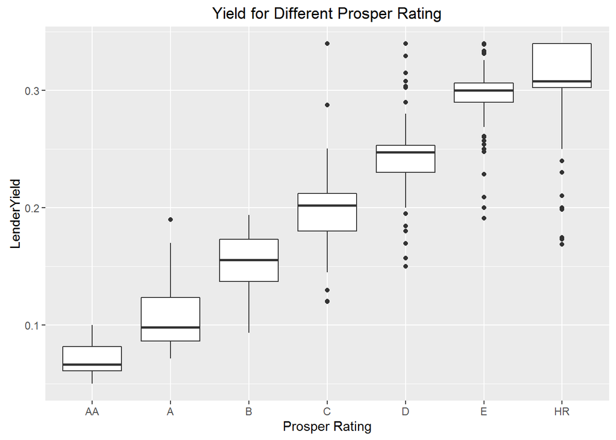

There seems to be an inverse relationship here.

The loan amount in terms of the repayment terms can be determined to get an idea if people are aware of the ability to repay higher loans.

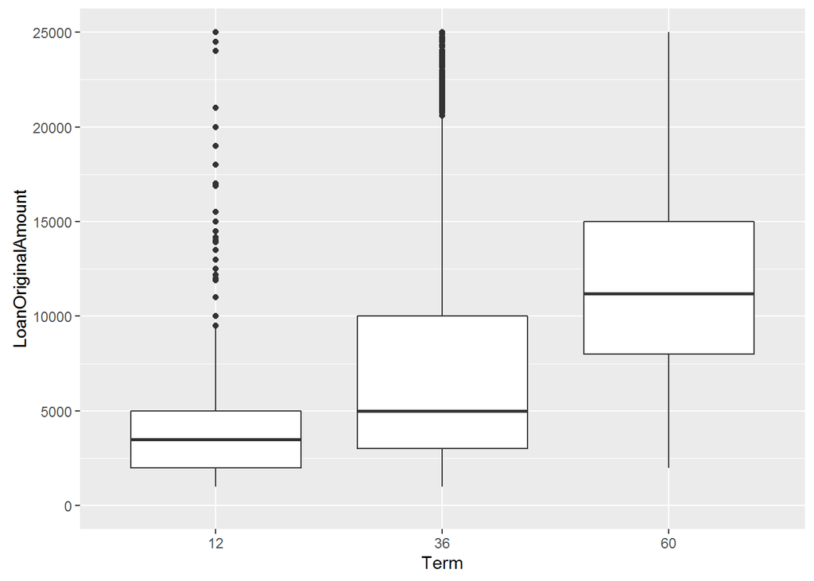

There is a direct relationship between the loan term and the amount of loan which is quite sensible and good.

## Multivariate Analysis

The lender yield should be dependent on the prosper rating which in turn should be dependent on the debt to income ratio.

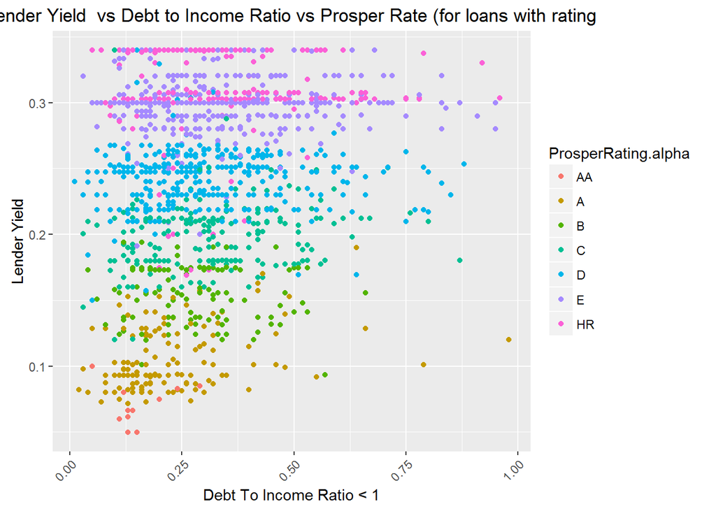

Lets take a look if the year of the loan depends on the prosper rating.

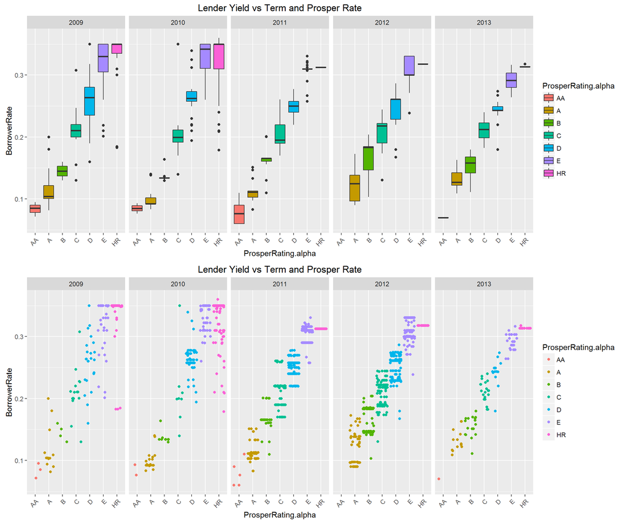

We can see that the borrower rates based on prosper rating shows stability over all the years establishing the fact that the data from propser is credible and the borrower pattern has not changed.

## Final Plots and Summary

### Plot one

The relationship between lender yield and prosper rating shows that the higher the risk, the lower the rating and better lender yield. Also people with higher rating have less debt to income ratio thus contributing to the prosper rating.

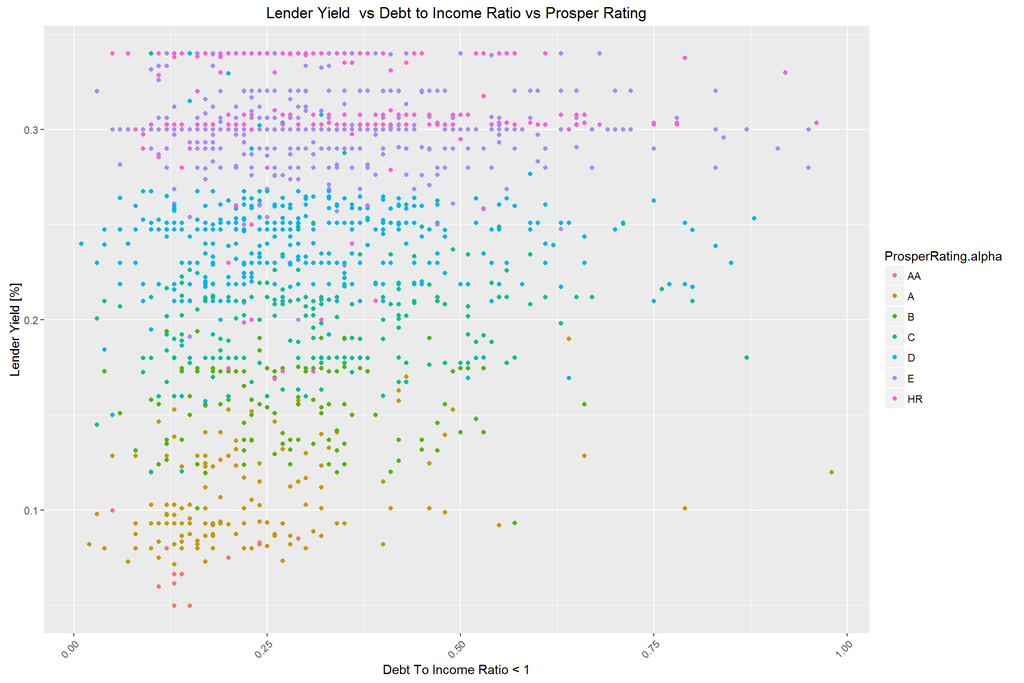

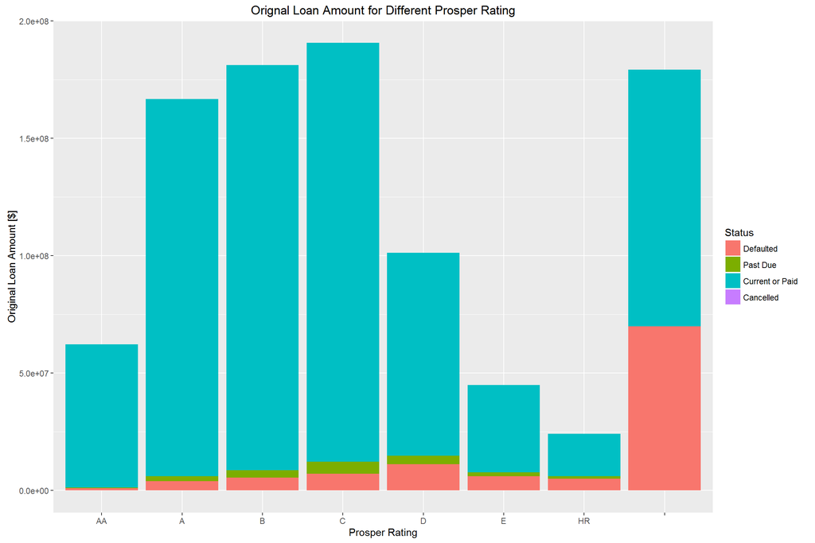

The final one is the loans taken by years which clearly depicts the recession period in USA and the confidence in people during those times to take loans.

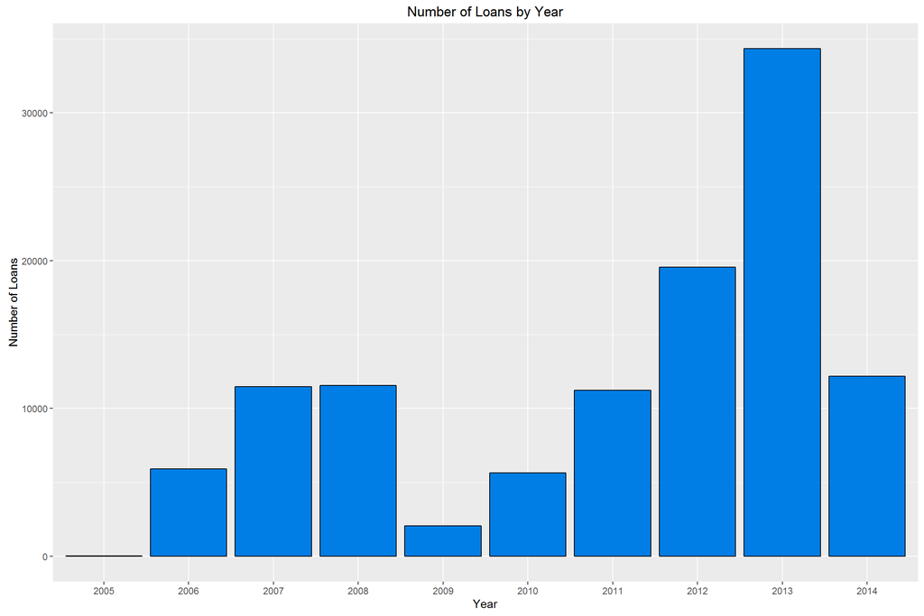

# Reflection

This is a complex dataset that I have been working on with a lot of variables and it’s really tough to identify and imply correlation from it. Since, I am still a student and possibly hoping to get a job and take loans in the future, I am not aware of most of the terms in the dataset. Since the dataset was tidy I was able to perform a few calculation to arrive at the answers that I am looking for. This gives me a lot of confidence in the future if I am facing a challenge to perform EDA to an unknown dataset. The most important variable from this dataset according to my perspective was the lender yield, the debt to income ratio and prosper rating. I would still like to know more about how they rate the borrowers since there is an indifferent correlation with the lenders trust on the rating. I am looking at the website to find answer for this. The debt to income ratio plays an important role in the borrowers mindset to obtain loans and also the lenders yield. With this information, further linear regression and predictive modeling can be performed to arrive at a pattern for the lenders as well as borrowers to make the process of obtaining and loan and implication associated with it more easier.

# References

- Prosper: How it works: https://www.prosper.com/welcome/how-it-works/
- Prosper Ratings: https://www.prosper.com/invest/how-to-invest/prosper-ratings/
- What Is in a Credit Score?: https://www.creditkarma.com/article/credit-score-factors
- MORE DESCRIPTIVE STATISTICS:http://ww2.coastal.edu/kingw/statistics/R-tutorials/descriptive.html
- Beautiful plotting in R: A ggplot2 cheatsheet: http://zevross.com/blog/2014/08/04/beautiful-plotting-in-r-a-ggplot2-cheatsheet-3/